# Прогноз количества заказов для сервиса такси

## Описание проекта

Заказчик - компания такси - собрал исторические данные о заказах такси в аэропортах. Чтобы привлекать больше водителей в период пиковой нагрузки, нужно спрогнозировать количество заказов такси на следующий час. Надо построить модель для такого предсказания.

Значение метрики *RMSE* на тестовой выборке должно быть не больше 48.

### План проекта

1. Загрузить данные и выполнить ресемплирование по одному часу.
2. Проанализировать данные.
3. Обучить разные модели с различными гиперпараметрами. Тестовая выборка - 10% от исходных данных.
4. Проверить модели на тестовой выборке, сделать выводы.

### Описание данных

Данные лежат в файле `taxi.csv`. Количество заказов находится в столбце '*num_orders*'.

### План работы

1. Подготовка  
   1.0. Импорт библиотек  
   1.1. Загрузка данных  
   1.2. Подготовка данных: исследование на пропуски и выбросы
2. Анализ  
   2.1. Преобразование временного интервала  
   2.2. Разложение на тренд, сезонность и остатки для всего периода  
   2.3. Исследование внутридневного графика  
   2.4. Выводы
3. Обучение  
   3.1. Подготовка признаков  
   3.2. Рабиение на выборки  
   3.3. Обучение моделей методом кросс-валидации  
   3.3.1. LinearRegression  
   3.3.2. RandomForrestRegressor  
   3.3.3. CatBoostRegressor
4. Тестирование  
   4.1. Тестирование всех моделей на тестовой выборке  
   4.2. Выбор лучшей  
   4.3. График предсказания для всей выборки  
   4.4. Заключение

# 1. Подготовка

План работы на раздел:

1.0. Импорт библиотек  
1.1. Загрузка данных  
1.2. Подготовка данных: исследование на пропуски и выбросы

## 1.0. Загрузка библиотек

Приступим. Для начала импортируем необходимые библиотеки.

```python
# importing necessary libraries
# data processing
import numpy as np
import pandas as pd

# time serie decomposing
from statsmodels.tsa.seasonal import seasonal_decompose

# machine learning
from sklearn.model_selection import train_test_split
from sklearn.model_selection import TimeSeriesSplit
from sklearn.model_selection import GridSearchCV
from sklearn.metrics import mean_squared_error
from sklearn.metrics import make_scorer
from sklearn.linear_model import LinearRegression
from sklearn.ensemble import RandomForestRegressor
from catboost import CatBoostRegressor

# visualization
import matplotlib.pyplot as plt

# common utilities
from datetime import datetime

print('importing libraries - OK')
```

```
importing libraries - OK
```

# 1.1. Загрузка данных

Теперь можно загрузить файл и рассмотреть в подробностях. Парсинг меток времени и превращение их в индекс произведём на лету.

```python
# loading time serie
data = pd.read_csv('/datasets/taxi.csv', index_col=[0], parse_dates=[0])
data.sort_index(inplace=True)

data.head(5)
```

| datetime | num_orders |
| --- | --- |
| 2018-03-01 00:00:00 | 9 |
| 2018-03-01 00:10:00 | 14 |
| 2018-03-01 00:20:00 | 28 |
| 2018-03-01 00:30:00 | 20 |
| 2018-03-01 00:40:00 | 32 |

5 секунд, полёт нормальный. Можно сделать первые выводы:

1. Данные загрузились, метки времени распознались.
2. Периодичность меток - 10 минут.

# 1.2. Подготовка данных

Исследуем данные в различных аспектах:

1. Длина периода наблюдений
2. Пропуски
3. Выбросы

```python
print('start time -', data.index.min())
print('finish time -', data.index.max())
```

```
start time - 2018-03-01 00:00:00
finish time - 2018-08-31 23:50:00
```

Имеем данные с 1-го марта 2018-го по 31-е августа 2018-го года, то есть полгода.

Исследуем общую информацию.

```python
data.info()
```

```
<class 'pandas.core.frame.DataFrame'>
DatetimeIndex: 26496 entries, 2018-03-01 00:00:00 to 2018-08-31 23:50:00
Data columns (total 1 columns):
num_orders    26496 non-null int64
dtypes: int64(1)
memory usage: 414.0 KB
```

Пропусков нет, отлично.

Посмотрим распределение.

```python
data.describe()
```

|  | num_orders |
| --- | --- |
| count | 26496.000000 |
| mean | 14.070463 |
| std | 9.211330 |
| min | 0.000000 |
| 25% | 8.000000 |
| 50% | 13.000000 |
| 75% | 19.000000 |
| max | 119.000000 |

Построим боксплот.

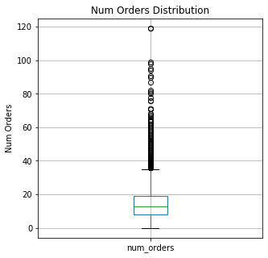

```python
axes = data.boxplot(column=['num_orders'],
              by=None, ax=None, fontsize=None, rot=0, grid=True, figsize=(5, 5), layout=None, return_type=None)
axes.set_ylabel('Num Orders')
axes.set_title('Num Orders Distribution')
plt.show()
```

Боксплот считает, что всё, что выше 40 заказов в 10 минут - выбросы. Здесь хорошо бы посоветоваться с заказчиком. Из жизненного опыта, в некоторых случаях такое возможно. Примем к сведению, более детально проанализируем в следующем разделе с привязкой ко времени.

Посмотрим диаграмму распределения.

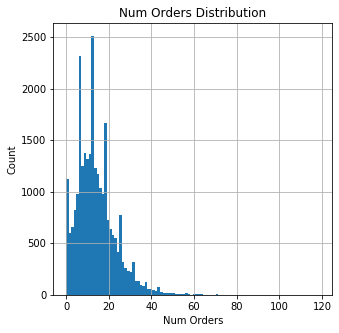

```python
axes = data.hist(column='num_orders', bins=100,
              by=None, ax=None, grid=True, figsize=(5, 5), layout=None)
plt.xlabel('Num Orders')
plt.ylabel('Count')
plt.title('Num Orders Distribution')
plt.show()
```

Похоже, что значения больше 40 заказов в 10 минут действительно можно считать выбросами. Следует посоветоваться с заказчиком.  
Построим график, взглянем на сырые данные.

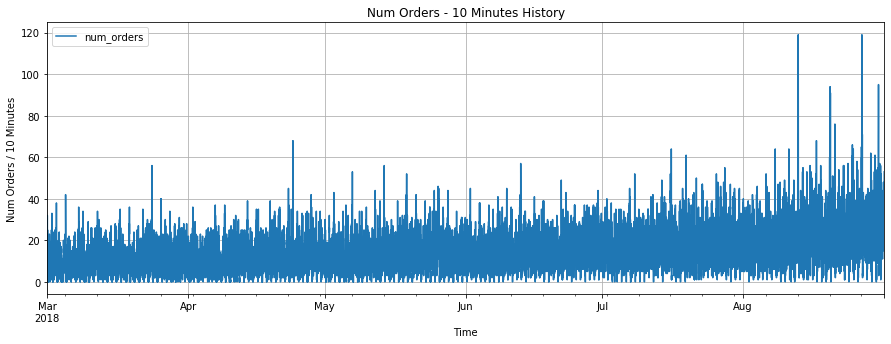

```python
data.plot(y='num_orders', grid=True, figsize=(15, 5))
plt.xlabel('Time')
plt.ylabel('Num Orders / 10 Minutes')
plt.title('Num Orders - 10 Minutes History')
plt.show()
```

Пушисто. Здесь 40 заказов в 10 минут уже не кажется аномалией, так как с течением времени таких значений становится всё больше. Так же как и максимальных в 120 заказов. В чём и состоит отличие временных рядов от обычных наборов данных. Всё меняется со временем. Если что-то повторяется всё чаще и чаще, значит это уже тенденция. Здесь это похоже на тенденцию.

# 2. Анализ

План работы на раздел:

2.1. Преобразование временного интервала  
2.2. Разложение на тренд, сезонность и остатки для всего периода  
2.3. Исследование внутридневного графика

Прежде всего, переформируем данные в часовые интервалы в соответствии с заданием.

## 2.1. Преобразование временного интервала

Изготовим 2 временных ряда:

1. По часам
2. По дням

Первый потребуется для обучения моделей. На втором удобнее стрроить визуализацию, так как часовой график получится слишком пушистым.

```python
# resampling by 1 hour
data_h = data.resample('1H').sum()
data_d = data.resample('1D').sum()
```

Исходный датасет ещё пригодится.  
Убедимся, что всё прошло гладко, построим графики для каждого преобразованного временного ряда.

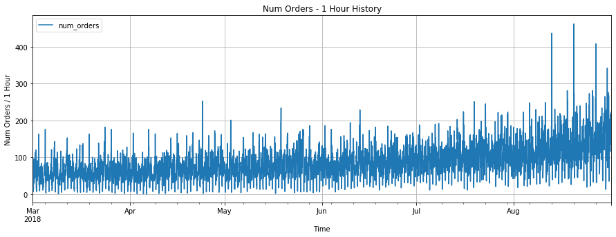

```python
data_h.plot(y='num_orders', grid=True, figsize=(15, 5))
plt.xlabel('Time')
plt.ylabel('Num Orders / 1 Hour')
plt.title('Num Orders - 1 Hour History')
plt.show()
```

Как и ожидалось, часовой график неудобен для визуального анализа. Далее будем анализировать дневной график.

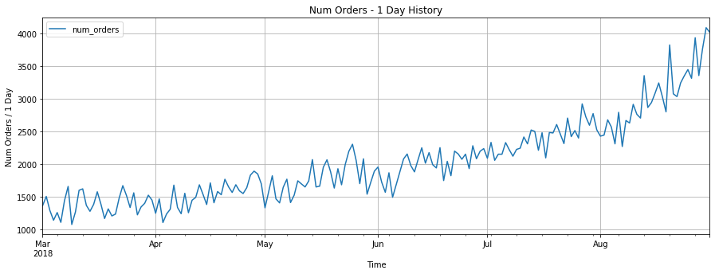

```python
data_d.plot(y='num_orders', grid=True, figsize=(15, 5))
plt.xlabel('Time')
plt.ylabel('Num Orders / 1 Day')
plt.title('Num Orders - 1 Day History')
plt.show()
```

Можно сказать, что дела у сервиса идут в гору в прямом и переносном смысле. Наблюдается тренд и некие колебания вокруг него. Тренд является мультипликативным, то есть растёт не по прямой, а по параболе.

## 2.2. Разложение на тренд, сезонность и остатки

Разложим ряд на составляющие.

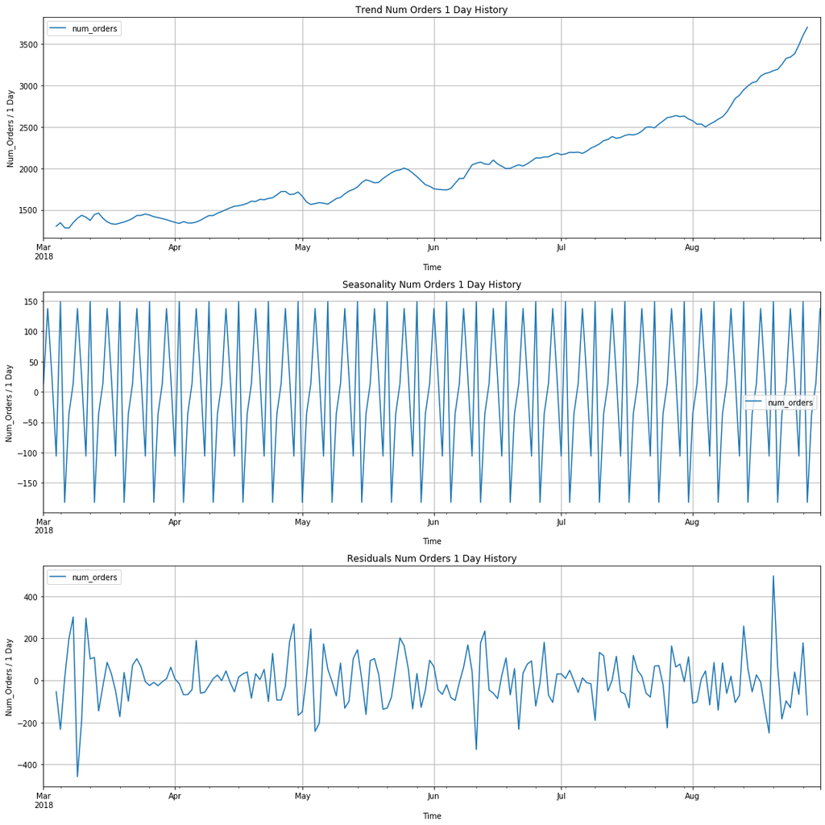

```python
# day-chart decomposition
data_d_decomposed = seasonal_decompose(data_d)

# plotting
plt.figure(figsize=(15, 15))
plt.subplot(311)
data_d_decomposed.trend.plot(ax=plt.gca(), grid=True)
plt.title('Trend Num Orders 1 Day History')
plt.xlabel('Time')
plt.ylabel('Num_Orders / 1 Day')
plt.subplot(312)
data_d_decomposed.seasonal.plot(ax=plt.gca(), grid=True)
plt.title('Seasonality Num Orders 1 Day History')
plt.xlabel('Time')
plt.ylabel('Num_Orders / 1 Day')
plt.subplot(313)
data_d_decomposed.resid.plot(ax=plt.gca(), grid=True)
plt.title('Residuals Num Orders 1 Day History')
plt.xlabel('Time')
plt.ylabel('Num_Orders / 1 Day')
plt.tight_layout()
```

Подозрения по поводу мультипликативного характера тренда крепнут. Тренд не просто растёт, он ускоряется. Хорошая новость для сервиса. Не очень хорошая для дата сайентиста. Такие тренды модели воспринимают хуже.

И тут вспомним про такое интересное средство удаления мультипликативности, как логарифмирование. Используем его и повторим декомпозицию.

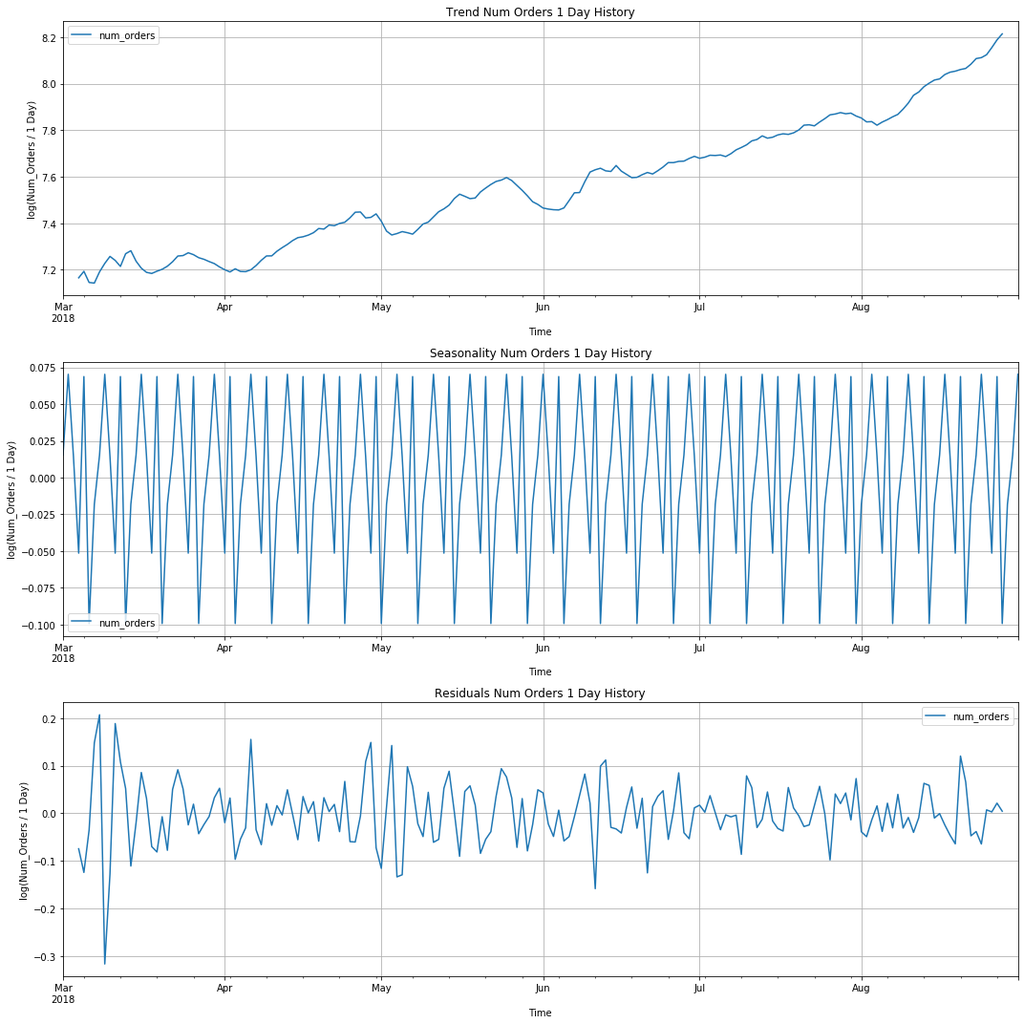

```python
# day chart decomposition with logarithm
data_2_log_decomposed = seasonal_decompose(np.log(data_d))

# plotting
plt.figure(figsize=(15, 15))
plt.subplot(311)
data_2_log_decomposed.trend.plot(ax=plt.gca(), grid=True)
plt.title('Trend Num Orders 1 Day History')
plt.xlabel('Time')
plt.ylabel('log(Num_Orders / 1 Day)')
plt.subplot(312)
data_2_log_decomposed.seasonal.plot(ax=plt.gca(), grid=True)
plt.title('Seasonality Num Orders 1 Day History')
plt.xlabel('Time')
plt.ylabel('log(Num_Orders / 1 Day)')
plt.subplot(313)
data_2_log_decomposed.resid.plot(ax=plt.gca(), grid=True)
plt.title('Residuals Num Orders 1 Day History')
plt.xlabel('Time')
plt.ylabel('log(Num_Orders / 1 Day)')
plt.tight_layout()
```

Тренд стал прямее. Запомним этот факт. Можно применить для формирования признаков. Главное, не забыть потом произвести обратное преобразование для предсказания.

Какие можно сделать выводы по блоку:

1. Есть растущий тренд. Тренд растёт мультипликативно. Логарифмирование не спрямило линию полностью, значит, там есть парабола более чем 2-го порядка.
2. Наблюдается отчётливая сезонность с периодом одна неделя. Это можно объяснить тем, что расписания рейсов в аэропортах тоже имеют недельную сезонность, когда рейсы вылетают регулярно по определённым дням недели. Следует иметь это в виду.
3. Есть довольно большая случайная составляющая в остатках, которая, однако, уменьшается со временем. Это может снизить точность, так как случайную составляющую предсказать невозможно.

## 2.3. Исследование внутридневного графика

Интересно исследовать так же, что происходит с заказами внутри дня.  
Возьмём любой день - например, 1-е июля - и посмотрим на часовой график.

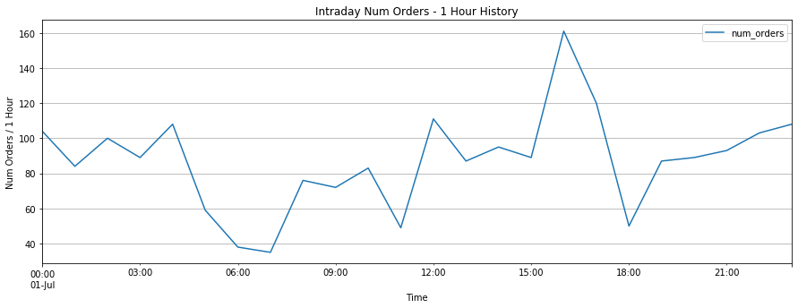

```python
data_h['2018-07-01':'2018-07-01'].plot(y='num_orders', grid=True, figsize=(15, 5))
plt.xlabel('Time')
plt.ylabel('Num Orders / 1 Hour')
plt.title('Intraday Num Orders - 1 Hour History')
plt.show()
```

На примере одного дня на часовом графике можем сделать следующие выводы:

1. С 0 часов до примерно 4-х утра наблюдается флэт, то есть количество заказов стоит на одном, среднем, уровне.
2. Далее идёт провал, достигая минимальных значений в промежутке с 6-ти до 7-ми утра.
3. Затем начинается дневаня активность с пиком заказов между 15-ю и 16-ю часами.
4. Затем второй суточный спад в 18:00, после чего кривая постепенно выходит на ночной уровень.

Очевидно, это так же связано с расписаниями рейсов. Интересно, что минимумы имеют периодичность в 12 часов. Очевидно, в эти моменты удобно было бы производить пересменки водителей.

Исследуем дневной график на 10-минутных интервалах с разложением на составляющие.

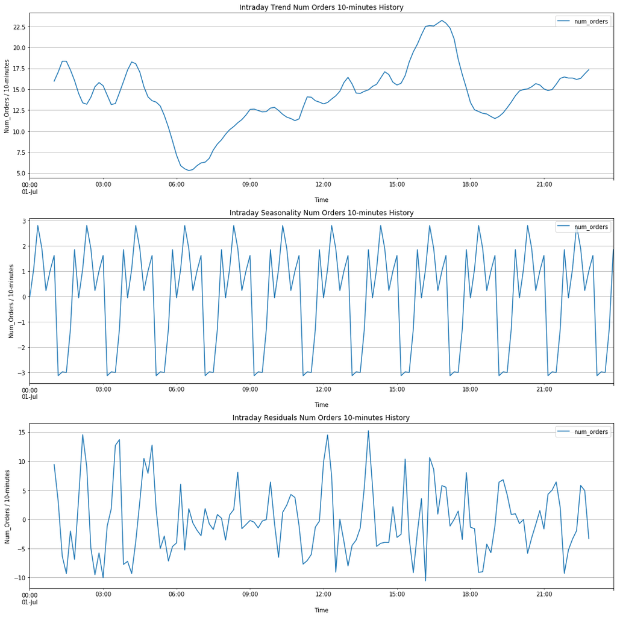

```python
# 10-minutes intraday chart decomposition
data_decomposed = seasonal_decompose(data['2018-07-01':'2018-07-01'], freq=6*2)

# plotting
plt.figure(figsize=(15, 15))
plt.subplot(311)
data_decomposed.trend.plot(ax=plt.gca(), grid=True)
plt.title('Intraday Trend Num Orders 10-minutes History')
plt.xlabel('Time')
plt.ylabel('Num_Orders / 10-minutes')
plt.subplot(312)
data_decomposed.seasonal.plot(ax=plt.gca(), grid=True)
plt.title('Intraday Seasonality Num Orders 10-minutes History')
plt.xlabel('Time')
plt.ylabel('Num_Orders / 10-minutes')
plt.subplot(313)
data_decomposed.resid.plot(ax=plt.gca(), grid=True)
plt.title('Intraday Residuals Num Orders 10-minutes History')
plt.xlabel('Time')
plt.ylabel('Num_Orders / 10-minutes')
plt.tight_layout()
```

Библиотека не смогла подобрать период сезонности автоматически, пришлось поэкспериментировать с ручными параметрами. С 2-часовой сезнностью кажется самым наглядным.

Здесь подтверждается вывод о внутридневных колебаниях, причём минимум и максимум дня отстоят друг от друга примерно на 12 часов. Сезонность в течение дня небольшая, зато большая случайная составляющая. Очевидно, придётся смириться с тем, что уменьшить ошибку модели ниже среднего значения случайной составляющей не удастся.

## 2.4. Выводы

Почему так много времени уделяем анализу ряда на различных промежутках и в различных шкалах? Потому что временной ряд подобен факториалу - повторяет сам себя на более крупных масштабах. Там, где работают с временными рядами - на финанасовых рынках или в управлении технологическими процессами - строят и анализируют большое количество рядов с различными масштабами.

Итак, что имеем:

1. Есть общий тренд, он растущий и мультипликативный, более чем 2-го порядка.
2. Присутствуют как минимум две сезонности: недельная и 24-часовая.
3. Достаточно велика случайная составляющая, что является теоретическим пределом для качества модели.

# 3. Обучение

План на раздел:

3.1. Подготовка признаков  
3.2. Рабиение на выборки  
3.3. Обучение моделей методом кросс-валидации  
3.3.1. LinearRegression  
3.3.2. RandomForestRegressor  
3.3.3. CatBoostRegressor

Для исследования специально взяты модели трёх разных типов - линейная регрессия, ансамбль деревьев и бэггинг деревьев, чтобы понять, какой из типов подходит к данной задаче лучше.

## 3.1. Подготовка признаков

Выбор и подготовка признаков - это самый ответственный этап при работе с временными рядами. Если удастся подобрать признаки, которые действительно зависят от времени и влияют на цель, модель будет максимально точной. И наоборот.

Что можно выделить уже сейчас:

1. Заменить даты на последовательно увеличивающиеся номера наблюдений.
2. Ввести номер часа в сутках, чтобы учесть внутридневные сезонности.
3. Ввести номер дня в неделе, чтобы учесть внутринедельные сезонности.
4. Ввести лаги в 12 и 24 часа, для внутридневной сезонности.
5. Ввести лаг в 7 * 24 часа, для недельной сезонности.
6. Ввести скользящие средние в 12, 24, 7 * 24 часов.
7. Ввести квадрат номера наблюдения, чтобы учесть нелинейность тренда.

И там ещё посмотрим.

С логарифмированием связываться не будем, так как это требует обратного преобразования предсказания. Двухэтапный процесс в эксплуатации кажется менее надёжным, чем одноэтапный.

```python
# numbering rows
data_h['number'] = data_h.reset_index().index

# parabolic numbers
data_h['number_2'] = data_h['number'] * data_h['number']

# hour, day of week numbers
data_h['hour'] = data_h.index.hour
data_h['dayofweek'] = data_h.index.dayofweek

# lags 12, 24, 7*24 hours
data_h['lag_12'] = data_h['num_orders'].shift(12)
data_h['lag_24'] = data_h['num_orders'].shift(24)
data_h['lag_7_24'] = data_h['num_orders'].shift(7 * 24)

# moving averages 12, 24, 7*24 hours
data_h['ma_12'] = data_h['num_orders'].shift(1).rolling(12).mean()
data_h['ma_24'] = data_h['num_orders'].shift(1).rolling(24).mean()
data_h['ma_7_24'] = data_h['num_orders'].shift(1).rolling(7 * 24).mean()

# dropping nans
data_featured = data_h.dropna()
data_featured
```

| datetime | num_orders | number | number_2 | hour | dayofweek | lag_12 | lag_24 | lag_7_24 | ma_12 | ma_24 | ma_7_24 |
| --- | --- | --- | --- | --- | --- | --- | --- | --- | --- | --- | --- |
| 2018-03-08 00:00:00 | 143 | 168 | 28224 | 0 | 3 | 34.0 | 100.0 | 124.0 | 69.250000 | 60.041667 | 54.226190 |
| 2018-03-08 01:00:00 | 78 | 169 | 28561 | 1 | 3 | 55.0 | 121.0 | 85.0 | 78.333333 | 61.833333 | 54.339286 |
| 2018-03-08 02:00:00 | 65 | 170 | 28900 | 2 | 3 | 43.0 | 24.0 | 71.0 | 80.250000 | 60.041667 | 54.297619 |
| 2018-03-08 03:00:00 | 68 | 171 | 29241 | 3 | 3 | 51.0 | 66.0 | 66.0 | 82.083333 | 61.750000 | 54.261905 |
| 2018-03-08 04:00:00 | 60 | 172 | 29584 | 4 | 3 | 46.0 | 73.0 | 43.0 | 83.500000 | 61.833333 | 54.273810 |
| ... | ... | ... | ... | ... | ... | ... | ... | ... | ... | ... | ... |
| 2018-08-31 19:00:00 | 136 | 4411 | 19456921 | 19 | 4 | 46.0 | 72.0 | 113.0 | 163.416667 | 164.875000 | 154.297619 |
| 2018-08-31 20:00:00 | 154 | 4412 | 19465744 | 20 | 4 | 182.0 | 142.0 | 179.0 | 170.916667 | 167.541667 | 154.434524 |
| 2018-08-31 21:00:00 | 159 | 4413 | 19474569 | 21 | 4 | 203.0 | 198.0 | 166.0 | 168.583333 | 168.041667 | 154.285714 |
| 2018-08-31 22:00:00 | 223 | 4414 | 19483396 | 22 | 4 | 191.0 | 158.0 | 242.0 | 164.916667 | 166.416667 | 154.244048 |
| 2018-08-31 23:00:00 | 205 | 4415 | 19492225 | 23 | 4 | 167.0 | 246.0 | 173.0 | 167.583333 | 169.125000 | 154.130952 |

4248 rows × 11 columns

Разобьём на обучающую и тестовую выборки с соотношением, как в задании, - 9:1. Валидационную выборку использовать не будем, так применим метод кросс-валидации для подбора параметров.

```python
def splitting(data):
    return train_test_split(data, shuffle=False, test_size=0.1)

# splitting to train, test subsamples
train, test = splitting(data_featured)

print('train.shape =', train.shape)
print('test.shape =', test.shape)
```

```
train.shape = (3823, 11)
test.shape = (425, 11)
```

Разобьём на признаки и цели.

```python
def X_y_splitting(train, test):
    X_train = train.drop(columns=['num_orders'])
    y_train = train['num_orders']
    X_test = test.drop(columns=['num_orders'])
    y_test = test['num_orders']
    return (X_train, y_train, X_test, y_test)

# features and targets
X_train, y_train, X_test, y_test = X_y_splitting(train, test)

print('X_train.shape =', X_train.shape)
print('y_train.shape =', y_train.shape)

print('X_test.shape =', X_test.shape)
print('y_test.shape =', y_test.shape)
```

```
X_train.shape = (3823, 10)
y_train.shape = (3823,)
X_test.shape = (425, 10)
y_test.shape = (425,)
```

Прежде, чем приступим к обучению, подготовим собственную функцию потерь для алгоритма подбора гиперпараметров.

```python
def rmse(y_pred, y):
    return -np.sqrt(mean_squared_error(y_pred, y))

my_scorer = make_scorer(rmse)
```

Так же для временных рядов не подходит разбивка на случайные подвыборки, которая применятся обычно для перекрёстного поиска. Есть специальный класс, который формирует последовательные подвыборки, не нарушая порядок расположения наблюдений. То есть, чтобы модель не могла заглянуть в будущее. Создадим такой объект.

```python
# a special class for time series splitting
tscv = TimeSeriesSplit(n_splits=9)

print(tscv)
```

```
TimeSeriesSplit(max_train_size=None, n_splits=9)
```

## 3.3. Linear Regression

Начнём с линейной регрессии.

Линейная регрессия хорошо работает, когда цикличные признаки преобразованы техникой OHE. При этом надо не забыть удалить один элемент, чтобы не получить корреляции. Сделаем это перед началом обучения.

```python
# preparing data by OHE method
data_featured_ohe = pd.get_dummies(data_featured, columns=['hour', 'dayofweek'], drop_first=True)
train_ohe, test_ohe = splitting(data_featured_ohe)
X_train_ohe, y_train_ohe, X_test_ohe, y_test_ohe = X_y_splitting(train_ohe, test_ohe)
```

Запустим цикл подбора.

```python
%%time

# looking for best LinearRegression model
model = LinearRegression()

param_grid = {'fit_intercept' : [True, False], 'normalize' : [True, False]}

grid_search = GridSearchCV(model, param_grid, scoring=my_scorer, n_jobs=None, iid='deprecated',
             refit=True, cv=tscv, verbose=1, error_score='raise')

# cross-validating with timing
start_time = datetime.now().timestamp()
grid_search.fit(X_train_ohe, y_train_ohe)
time_spent_lr = datetime.now().timestamp() - start_time

best_model_lr = grid_search.best_estimator_
best_score_lr = -grid_search.best_score_

print()
print('best LinearRegression score is', best_score_lr)
```

```
Fitting 9 folds for each of 4 candidates, totalling 36 fits
```

```
[Parallel(n_jobs=1)]: Using backend SequentialBackend with 1 concurrent workers.
[Parallel(n_jobs=1)]: Done  36 out of  36 | elapsed:    9.0s finished
```

```
best LinearRegression score is 23.044699829934128
CPU times: user 3.5 s, sys: 5.93 s, total: 9.43 s
Wall time: 9.35 s
```

Лучший результат `RMSE` линейной регрессии при обучении получился **23.045**

## 3.4. RandomForestRegressor

Обучим случайный лес.

```python
%%time

# looking for best RandomForestRegressor model
model = RandomForestRegressor()

params = model.get_params()
params['criterion'] = 'mse'
#params['verbose'] = 25
model.set_params(**params)

param_grid = {
    'max_depth' : [2, 5, 10],
    'n_estimators' : [10, 100, 1000],
    'max_features' : ['auto', 'sqrt', 'log2']}

grid_search = GridSearchCV(model, param_grid, scoring=my_scorer, n_jobs=None, iid='deprecated',
             refit=True, cv=tscv, verbose=1, error_score='raise')

# cross-validating with timing
start_time = datetime.now().timestamp()
grid_search.fit(X_train, y_train)
time_spent_rf = datetime.now().timestamp() - start_time

best_model_rf = grid_search.best_estimator_
best_score_rf = -grid_search.best_score_

print()
print('best RandomForest score is', best_score_rf)
```

```
Fitting 9 folds for each of 27 candidates, totalling 243 fits
```

```
[Parallel(n_jobs=1)]: Using backend SequentialBackend with 1 concurrent workers.
[Parallel(n_jobs=1)]: Done 243 out of 243 | elapsed:  6.7min finished
```

```
best RandomForest score is 23.2542631852146
CPU times: user 6min 47s, sys: 973 ms, total: 6min 48s
Wall time: 6min 54s
```

Лучший результат `RMSE` случайного леса при обучении получился **23.254**

## 3.5. CatBoostRegressor

Обучим CatBoostRegressor.

```python
%%time

# looking for best CatBoost model
model = CatBoostRegressor()

params = model.get_params()
params['loss_function'] = 'RMSE'
params['iterations'] = 100
params['learning_rate'] = 1
#params['random_state'] = None
params['verbose'] = 100
model.set_params(**params)

param_grid = {
    'max_depth' : [2, 5, 10],
    'best_model_min_trees' : [10, 100, 1000],
    'learning_rate' : [0.25, 0.5, 0.75, 1]}

grid_search = GridSearchCV(model, param_grid, scoring=my_scorer, n_jobs=None, iid='deprecated',
             refit=True, cv=tscv, verbose=1, error_score='raise')

# cross-validating with timing
start_time = datetime.now().timestamp()
grid_search.fit(X_train, y_train)
time_spent_ct2 = datetime.now().timestamp() - start_time

best_model_ct2 = grid_search.best_estimator_
best_score_ct2 = -grid_search.best_score_

print()
print('best CatBoost score is', best_score_ct2)
```

```
Fitting 9 folds for each of 36 candidates, totalling 324 fits
```

```
[Parallel(n_jobs=1)]: Using backend SequentialBackend with 1 concurrent workers.
```

[output not shown]

[output cut: 593 more lines]

[output not shown]

```
[Parallel(n_jobs=1)]: Done 324 out of 324 | elapsed: 23.6min finished
```

```
0:	learn: 33.5302512	total: 10.2ms	remaining: 1.01s
99:	learn: 11.3180882	total: 7.93s	remaining: 0us

best CatBoost score is 24.83775389999121
CPU times: user 15min 25s, sys: 1min 30s, total: 16min 55s
Wall time: 23min 44s
```

Получили лучший результат `RMSE` CatBoost при обучении получился **24.838**

## 3.6. Результаты подбора

Сведём результаты в промежуточную таблицу.

```python
evaluation_results = pd.DataFrame()
evaluation_results['model_type'] = pd.Series(['LinearRegression', 'RandomForest', 'CatBoost'])
evaluation_results['evaluation_time, sec'] = pd.Series([time_spent_lr,
    time_spent_rf, time_spent_ct2])

evaluation_results['rmse_evaluation'] = pd.Series([
    best_score_lr,
    best_score_rf,
    best_score_ct2])

evaluation_results
```

|  | model_type | evaluation_time, sec | rmse_evaluation |
| --- | --- | --- | --- |
| 0 | LinearRegression | 9.351562 | 23.044700 |
| 1 | RandomForest | 414.913663 | 23.254263 |
| 2 | CatBoost | 1424.315752 | 24.837754 |

По точности на кросс-валидации все модели получились примерно одинаковы, а вот время подбора очень различается.

# 4. Тестирование

Перейдём к тестированию и выбору лучшей модели.

План на раздел:  
4.1. Тестирование всех моделей на тестовой выборке  
4.2. Выбор лучшей  
4.3. График предсказания для всей выборки  
4.4. Заключение

## 4.1. Тестирование всех моделей на тестовой выборке

Прежде, чем тестировать, обучим каждую модель на полной обучающей выборке.

### 4.1.1. LinearRegression

```python
%%time

# fitting
start_time = datetime.now().timestamp()
best_model_lr.fit(X_train_ohe, y_train_ohe)
time_spent_lr1 = datetime.now().timestamp() - start_time

# testing
start_time = datetime.now().timestamp()
y_predict = best_model_lr.predict(X_test_ohe)
time_spent_lr2 = datetime.now().timestamp() - start_time

# printing results
rmse_lr = np.sqrt(mean_squared_error(y_predict, y_test_ohe))
print('Testing LinearRegression: RMSE -', rmse_lr)
```

```
Testing LinearRegression: RMSE - 35.126796777371
CPU times: user 32.6 ms, sys: 19.7 ms, total: 52.3 ms
Wall time: 10.9 ms
```

### 4.1.2. RandomForestRegressor

```python
%%time

# fitting
start_time = datetime.now().timestamp()
best_model_rf.fit(X_train, y_train)
time_spent_rf1 = datetime.now().timestamp() - start_time

# testing
start_time = datetime.now().timestamp()
y_predict = best_model_rf.predict(X_test)
time_spent_rf2 = datetime.now().timestamp() - start_time

# printing results
rmse_rf = np.sqrt(mean_squared_error(y_predict, y_test))
print('Testing RandomForest: RMSE -', rmse_rf)
```

```
Testing RandomForest: RMSE - 41.02076067344766
CPU times: user 10.7 s, sys: 0 ns, total: 10.7 s
Wall time: 11.1 s
```

### 4.1.3. CatBoostRegressor

```python
%%time

# fitting
start_time = datetime.now().timestamp()
best_model_ct2.fit(X_train, y_train)
time_spent_ct21 = datetime.now().timestamp() - start_time

# testing
start_time = datetime.now().timestamp()
y_predict = best_model_ct2.predict(X_test)
time_spent_ct22 = datetime.now().timestamp() - start_time

# printing results
rmse_ct2 = np.sqrt(mean_squared_error(y_predict, y_test))
print('Testing CatBoost: RMSE -', rmse_ct2)
```

```
0:	learn: 33.5302512	total: 10.7ms	remaining: 1.05s
99:	learn: 11.3180882	total: 8s	remaining: 0us
Testing CatBoost: RMSE - 41.651211011955404
CPU times: user 7.44 s, sys: 762 ms, total: 8.21 s
Wall time: 9.3 s
```

## 4.2. Выбор лучшей модели

Сведём все результаты в таблицу.

```python
testing_results = pd.DataFrame()
testing_results['model_type'] = pd.Series(['LinearRegression', 'RandomForest', 'CatBoost'])
testing_results['training_time, sec'] = pd.Series([time_spent_lr1,
    time_spent_rf1, time_spent_ct21])
testing_results['testing_time, sec'] = pd.Series([time_spent_lr2,
    time_spent_rf2, time_spent_ct22])

testing_results['rmse_testing'] = pd.Series([rmse_lr, rmse_rf, rmse_ct2])

evaluation_results[['model_type', 'evaluation_time, sec', 'rmse_evaluation']].merge(testing_results, on='model_type')
```

|  | model_type | evaluation_time, sec | rmse_evaluation | training_time, sec | testing_time, sec | rmse_testing |
| --- | --- | --- | --- | --- | --- | --- |
| 0 | LinearRegression | 9.351562 | 23.044700 | 0.007252 | 0.001907 | 35.126797 |
| 1 | RandomForest | 414.913663 | 23.254263 | 10.929758 | 0.121232 | 41.020761 |
| 2 | CatBoost | 1424.315752 | 24.837754 | 9.296070 | 0.003048 | 41.651211 |

Получилось, что все модели удовлетворяют условию показать ошибку RMSE не более 48. При этом линейная регрессия показала наилучший результат на тестовой выборке - **35.127**. Предложим для производства модель **линейной регрессии**.

## 4.3. График предсказания

Сведём на одном графике реальные данные тестовой выборки и прогноз линейной регрессии, чтобы глазами увидеть, насколько они отличаются.

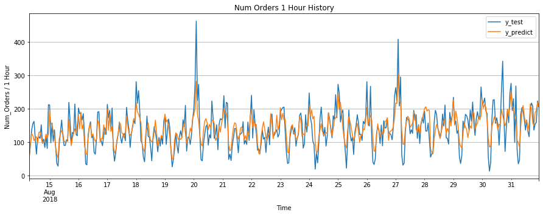

```python
y_predict = pd.Series(best_model_lr.predict(X_test_ohe), index=y_test.index)

plt.figure(figsize=(15, 5))
plt.subplot()
y_test.plot(ax=plt.gca(), grid=True, label='y_test')
y_predict.plot(ax=plt.gca(), grid=True, label='y_predict')
plt.title('Num Orders 1 Hour History')
plt.xlabel('Time')
plt.ylabel('Num_Orders / 1 Hour')
plt.legend()
plt.show()
```

Из графика видим, что предсказаное значение в среднем повторяет цель, отставая в экстремумах. Очевидно, стоит ещё поработать с признаками, чтобы отыскать эту составляющую. Возможно, имеет смысл подмешать данные более мелкого 10-минутного масштаба.

## 4.4. Заключение

Подведём итог.

Мы провели исследование временного ряда на предмет трендовых и сезонных закономерностей, случайной составляющей. Выяснили, что ряд имеет следующие характеристики:

1. Есть общий тренд, он растущий и мультипликативный, более чем 2-го порядка.
2. Присутствуют как минимум две сезонности: недельная и 24-часовая.
3. Достаточно велика случайная составляющая, что является теоретическим пределом для качества модели.

На основании полученной информации сформировали следующие признаки для обучения модели:

1. Заменили даты на последовательно увеличивающиеся номера наблюдений.
2. Ввели номер часа в сутках, чтобы учесть внутридневные сезонности.
3. Ввели номер дня в неделе, чтобы учесть внутринедельные сезонности.
4. Ввели лаги в 12 и 24 часа, для внутридневной сезонности.
5. Ввели лаг в 7 * 24 часа, для недельной сезонности.
6. Ввели скользящие средние в 12, 24, 7 * 24 часов.
7. Ввели квадрат номера наблюдения, чтобы учесть нелинейность тренда.

Далее провели подбор гиперпараметров для трёх типов моделей:

- Линейная регрессия
- Случайный лес
- CatBoost

Выяснили, что на обучающей выборке все модели показали практически одинаковое значение RMSE. Понятно, что ещё ничего не означает, поэтому провели тестировании.

По итогам тестирования определилось, что наилучшей оказалась линейная регрессия с RMSE около 35. Её и будем передавать в производство.

Есть ли возможности для улучшения точности модели? На мой взгляд, да. Следут поэкспериментировать с признаками. Например:

- Подмешать данные более старшего временного масштаба - 1 день
- Подмешать данные более мелкого масштаба - 10 минут
- Добавить скользящие средние по этим данным
- Добавить куб номера наблюдения.

Так же исследовать значимость признаков. Это вопрос, который мы здесь не рассматривали вовсе.

И ещё один момент - при эксплуатации предусмотреть переобучение модели каждую неделю. Характеристики временных рядов постепенно уходят. Модель должна следить за этим.